# Examining the topic of social inequality in archaeology: An quantitative approach

Liying Wang

### Introduction

The development of human societies is one of important topics in archaeology. Social inequality serves as a model to understand the mechanism of complex societies. In this paper, I will explore how archaeologists used the model of social inequality to explain prehistoric societies in past years by quantitative methods. My focuses include the development of social complexity over time, the cause for social complexity, and the relative archaeological evidence relates to this topic. I will conclude that social inequality serves as a new trend for studying complex societies and “power” or “ritual” is the key word to understand social inequality.

### Hypothesis testing

My research problems is how does social inequality develop and what is the relevant topic and evidence when we talk about social inequality. The terms “social inequality” and “social complexity” were usually discussed together, and sometimes there is no clear line between them. Thus, I want to explore the relationship between social inequality and social complexity. This will be helpful to understand the topic of social inequality in studies of complex society. My hypothesis is that if the social inequality is a new trend for study complex society, then results will show the stronger relationship between social inequality and complex society in recent years compared to the relationship between social complexity and complex society. In addition, social inequality is usually associated with some causes. I would like to examine the relationship between social inequality and culture contact, especially for the expansion of European in the 17th century. If culture contact is a cause relative to social inequality, then the result will show strong correlation.

I will explore “social inequality” in archaeology by using R as a quantitative method, and investigate how is the development of this model based on a large sample of archaeological literature over 50 years through JSTOR dataset. My research questions for this project as following:

1. How does the development of social inequality in archaeology in past decades? Is it popular at any particular time? How is the relationship between social inequality and social complexity?
2. How often social inequality relates to culture contact? Especially for European contact. Also, does any area show preference of such research, such as America, Asia, Oceania, or Africa?
3. What is the relationship between the term “inequality” and other archaeological evidence, including burials, ceramics, household, and glass beads? What other evidence or conditions relate to social inequality?

### Key words

Key words will be explored in this paper include social inequality, social complexity, complex society, culture contact, European contact, and other terms relate to archaeological evidence. Based on results from above words, I will also further examine relative terms. The term social inequality refers to power relation and principle of hierarchical structure in human society, and is usually associated with social complexity (Ames 2007; Bowles, Smith, and Mulder 2010; Price and Feinman 2010). Social complexity is a broader topic for research the development of social organization, and refers to a consequence of evolutionary process of growing differentiation and maintenance of the structural asymmetry (Laguens 2014; Arponen et al. 2015).

### Data Analysis

#### Frequencies and correlation of “social inequality” and “social complexity”

For the first question of the trend of social inequality, I examine frequencies of words of ”social inequality” and “social complexity” over time. Figure 1 shows that such discussion exists since 1978, became popular around 2000. The discussion of “social complexity” began from 1947, became popular around 1978, slightly declined at 1990 and 2006, and then was popular again at 2010. Figure 1 also shows that they have different patterns of frequency. When social inequality was frequently discussed, the frequency of social complexity became lower, and vice versa. This pattern could be observed at 1991, 1995, 2000, and 2005, which indicates that the terms of social inequality and social complexity might have some relationship of mutually exclusive. Results suggest that the discussion of social inequality could be viewed as more specific approach to complex societies, whereas social complexity is a broader topic which covers different discussion of social expects. Moreover, compared to social complexity, the discussion of social inequality emerged later around 1978, which implied that archaeologist focus more on social relation and power, which shows the emphasis of the anthropological thinking. This might relates to the development of post-processual archaeology from 1980 (Shanks and Hodder 2007).

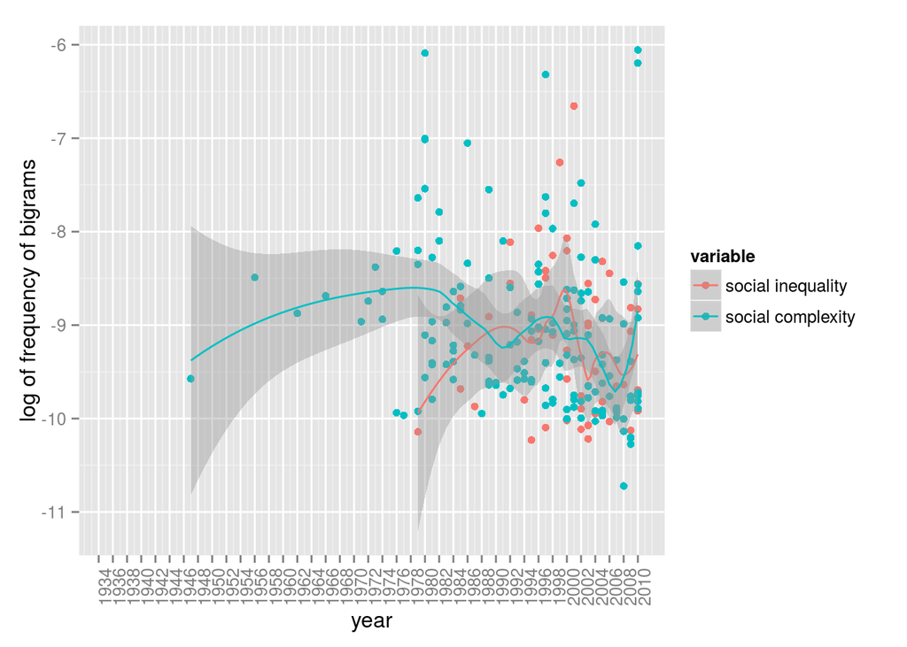

Figure 1: Social inequality and social complexity over time

I also examine the correlation between social inequality and social complexity. Figure 2 shows that they are strongly correlated at 1987, 1998, and 2007, which shows the periodic pattern of discussion, and might relate to review articles. For studies of complex society, Figure 3 and Figure 4 show that social inequality has strong correlation with complex society at 1981 and 1992, while social complexity is at 1977. This suggests that social inequality might be a trend to discuss complex societies. However, compared to social complexity, there is no much correlation between social inequality and complex society after 2000.

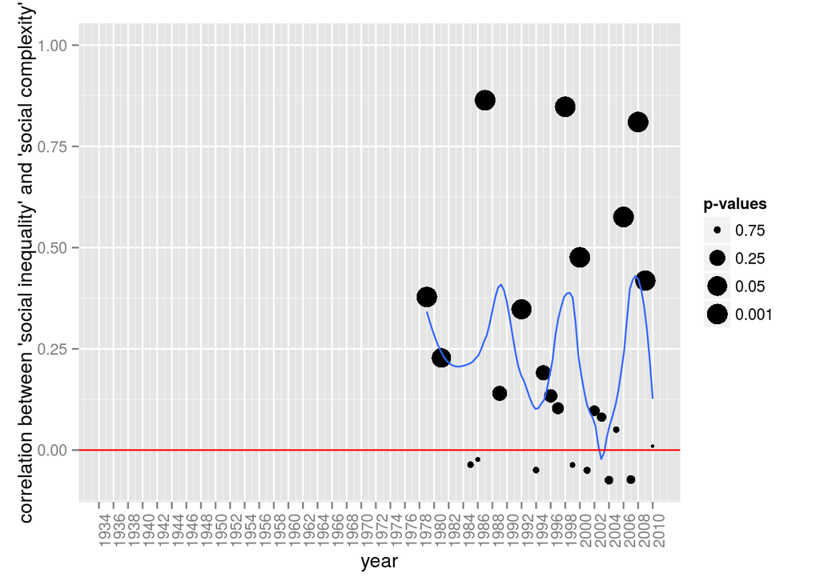

Figure 2: Correlation between social inequality and social complexity

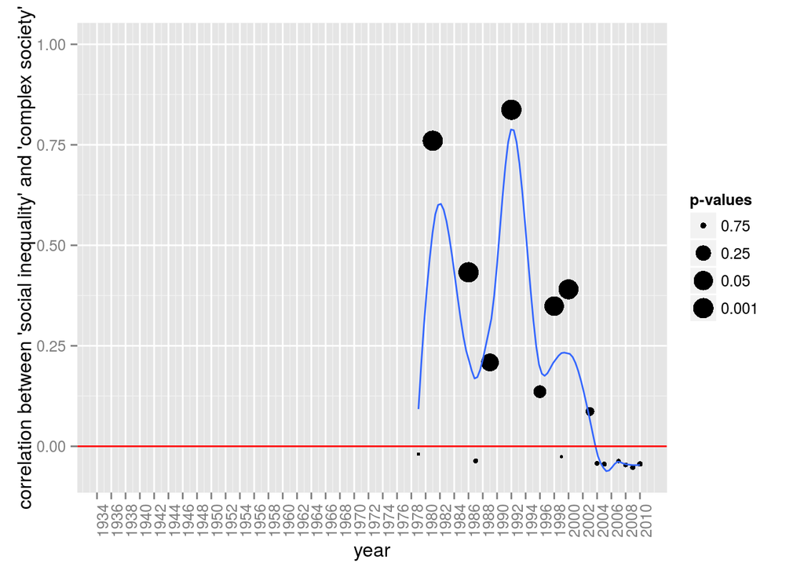

Figure 3: Correlation between social inequality and complex society

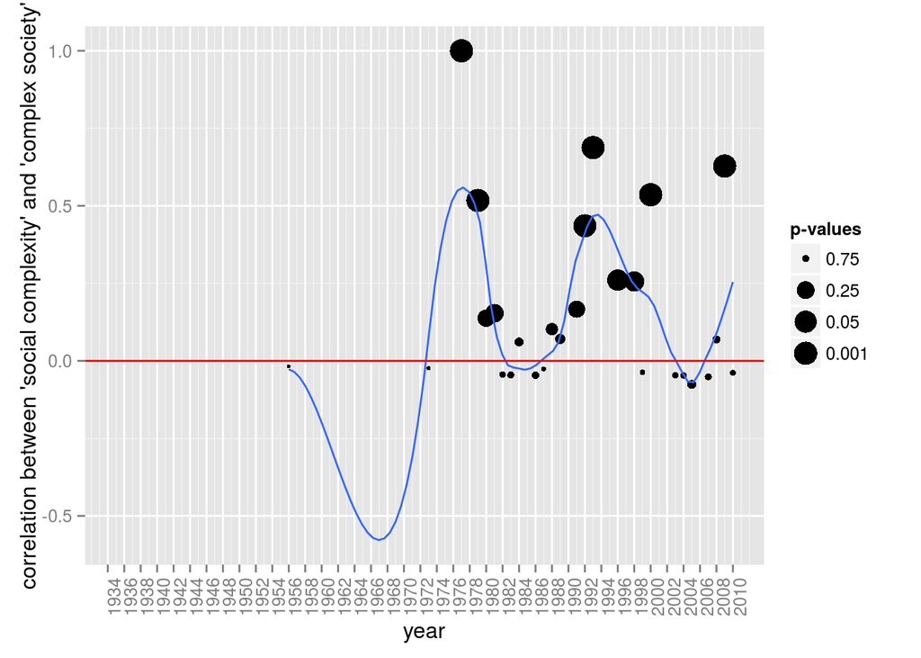

Figure 4: Correlation between social complexity and complex society

In order to explore the development and key points about social inequality, I further examine exact articles which both contain “social” and “inequality”. Fugire 5 shows that social and inequality were discussed together after 1978, and there are a couple of articles show strong correlation at 1978, 1985, and 2007. Based on results. These articles show that the discussion about social inequality shifts from exploring causes to the emphasis of cultural diversity and different type of inequality. Recent article suggests that there is no clear line between equality and inequality, and both principles can exist in a society (Crumley 1995). This change also indicates different theoretical frameworks in archaeology, explanatory approach and interpretive approach (Fogelin 2007; Jones and Alberti 2013). Compared with explanatory approach, interpretive approach focuses more on the diversity of inequality. The following are briefly annotated bibliography with strong correlation:

1. Sandra Montón Subías, 2007, Interpreting Archaeological Continuities: An Approach to Transversal Equality in the Argaric Bronze Age of South-East Iberia. World Archaeology, Vol. 39, No. 2, The Archaeology of Equality, pp. 246-262. Taylor & Francis, Ltd

In this paper, the author explored the social inequality based on women’s material culture and concluded that the concept of social transversal equality might be more appropriate to explain the discontinuities in material culture.

2. Bender, Barbara, 1985, “Emergent tribal formations in the American midcontinent.”American Antiquity: 52-62.

This author explored the cause for increasingly social differentiation in gather-hunter societies, and suggested that the alliance and exchange might exacerbate the social differentiation and inequality.

3. Bender, Barbara, 1978, “Gatherer‐hunter to farmer: A social perspective.” World archaeology 10.2: 204-222.

This paper focused on some properties of social organization among gatherer-hunters, and suggested that the development of social relations may promote the economic change.

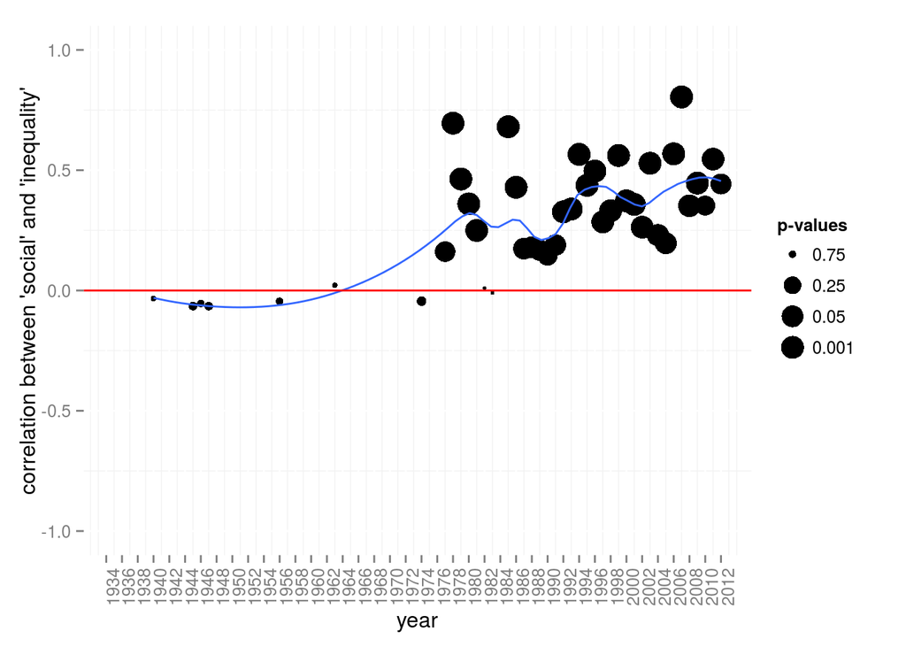

Figure 5: Correlation between social and inequality

#### Correlation of “social inequality” and “culture contact”

For the second question about the relationship between social inequality and culture contact, Figure 6 shows that there was a similar trend before 1994, but after 1994 there was no clear pattern shows the relationship. When we further examine the correlation between these two terms, Figure 7 indicates that there are a couple of articles with strong correlation at 1986, 1994, and 2007. This means culture contact might be a possible cause for social inequality. If we limit the culture contact to only European contact, Figure 8 shows that frequencies have similar pattern as the plot of culture contact. However, there is only one article with strong correlation between social inequality and European contact at 1986. This indicates that European contact might be not a common discussion for the topic of social inequality, or sometimes archaeologists use the term culture contact to incorporate the term European contact.

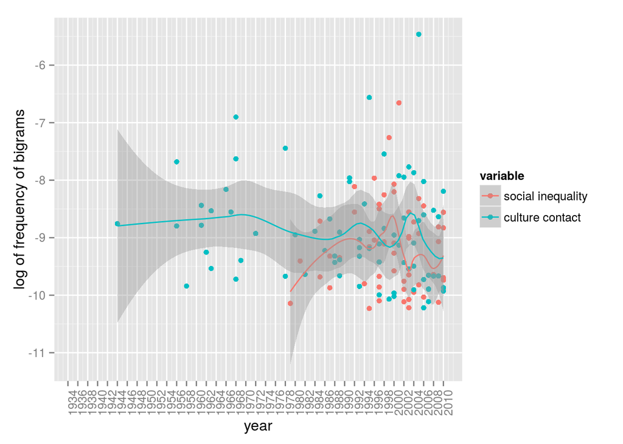

Figure 6: Two wrods “social inequality” and “cuture contact” over time

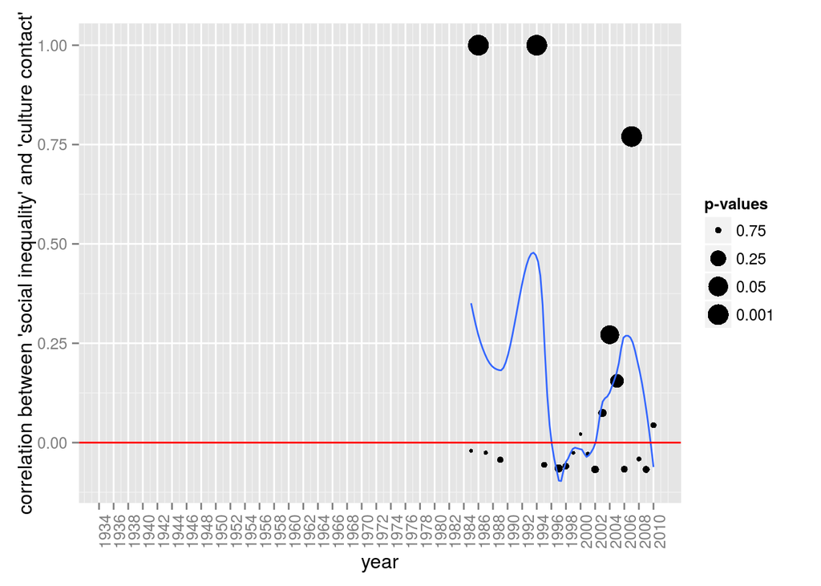

Figure 7: Correlation between social inequality and culture contact

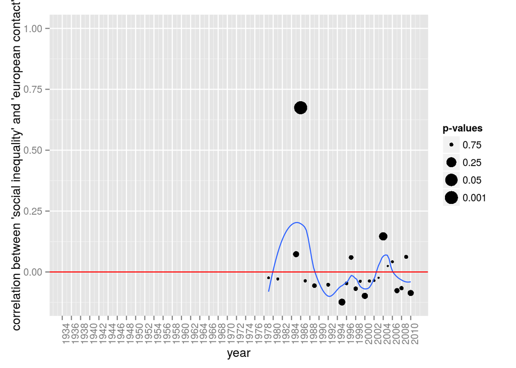

Figure 8: Correlation between social inequality and European contact

I further examine the topic of inequality in terms of different areas, including Asia, Oceania, America, and Africa. Results (Figure 9) show that in Asia, most articles contain inequality exist after 1978, and the term reached the highest frequency at 2004, but declined later at 2009. For Oceania (Figure 10), the trend shows there are two periods with higher frequency, which are 1996 and 2004. For America (Figure 11), there are more articles refer to inequality, and this term was popular around 2005. The pattern of frequency in Africa (Figure 12) looks similar to the pattern in America, and also shows the highest frequency at 2005. Although these four plots have different trends of the frequency of inequality, it seems social inequality was popular between 2004 and 2005 among these different areas. This indicates there might be some articles cover all of these areas. In addition, the frequency of inequality in America and Africa shows similar pattern, which might suggests there are some close relationship between them.

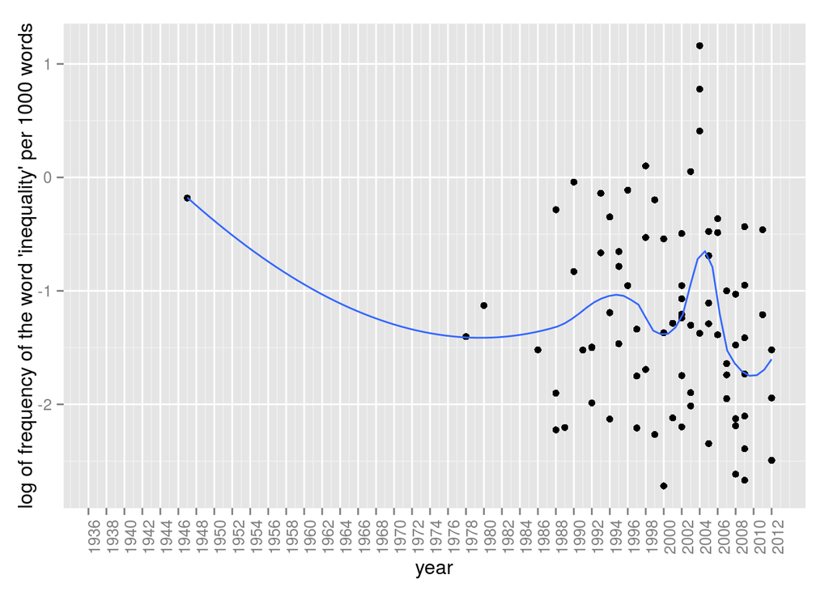

Figure 9: The word “Inequality” over time in studies relate to Asia

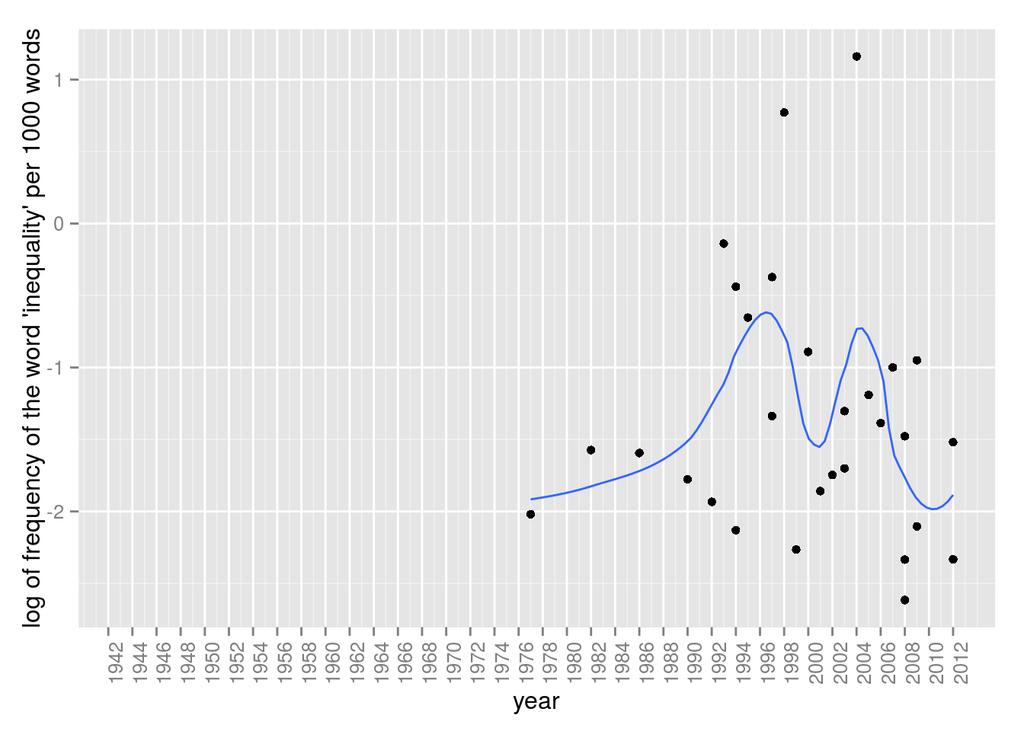

Figure 10: The word “Inequality” over time in studies relate to Oceania

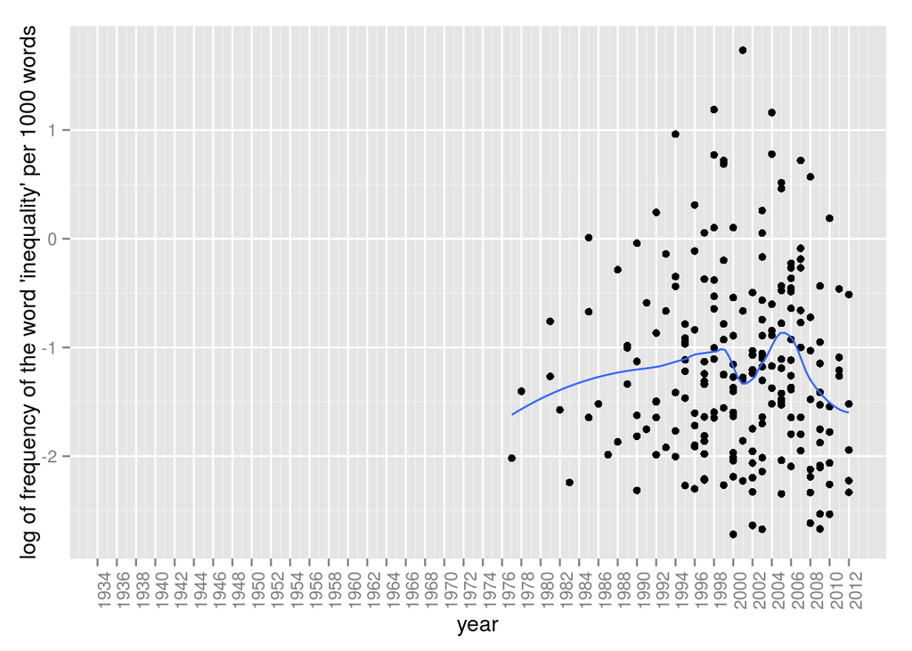

Figure 11: The word “Inequality” over time in studies relate to America

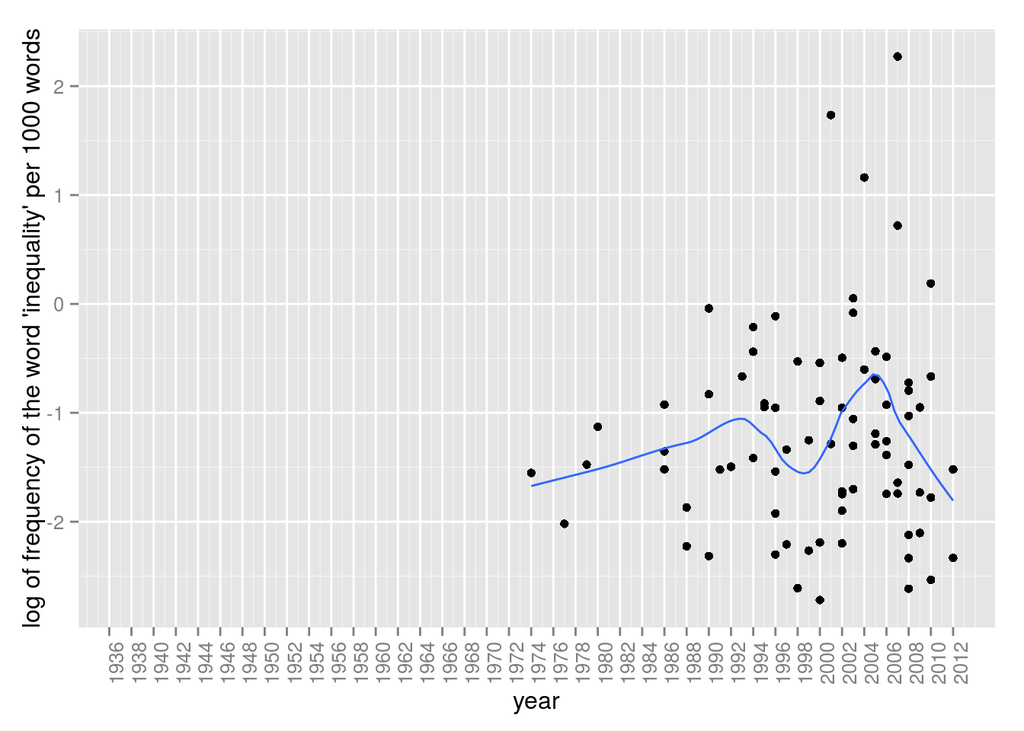

Figure 12: The word “Inequality” over time in studies relate to Africa

#### Archaeological evidence relates to social inequality

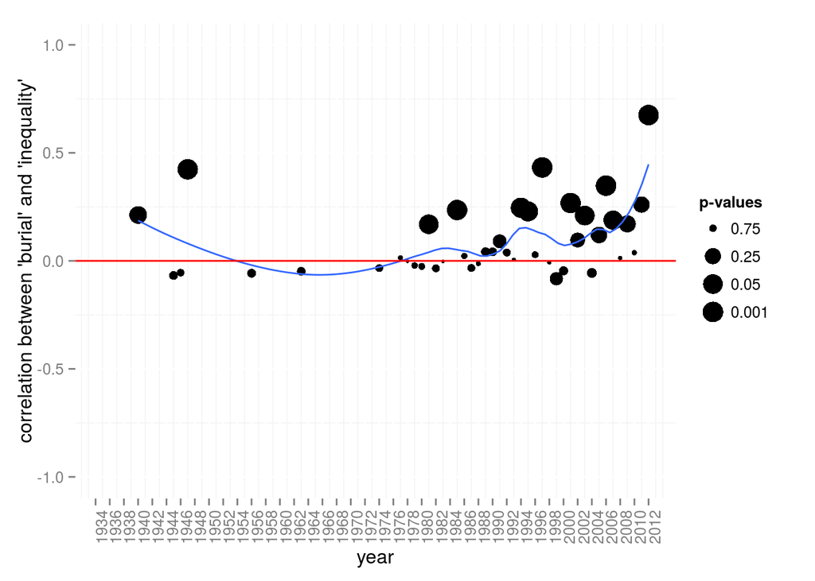

Figure 13: Correlation of inequality and burial

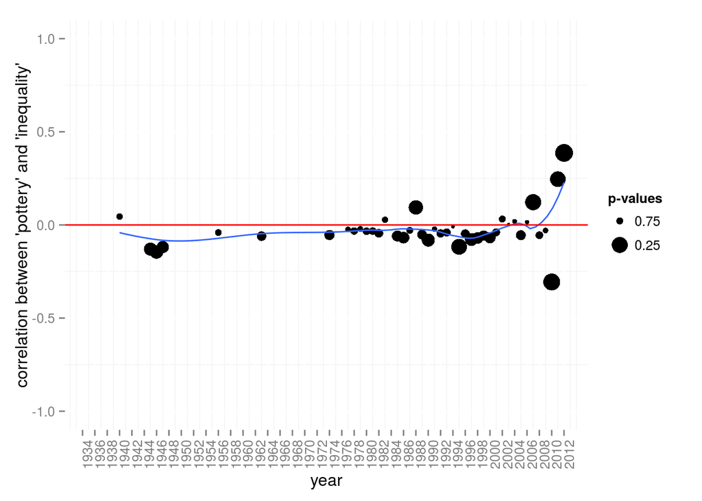

Figure 14: Correlation of inequality and pottery

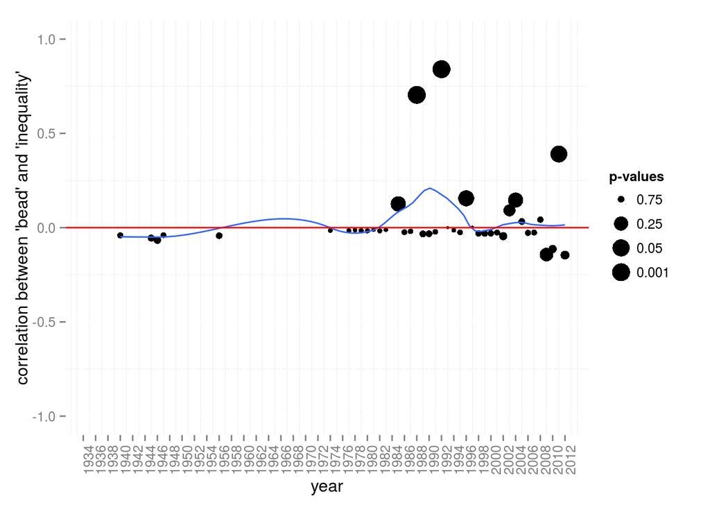

Figure 15: Correlation of inequality and bead

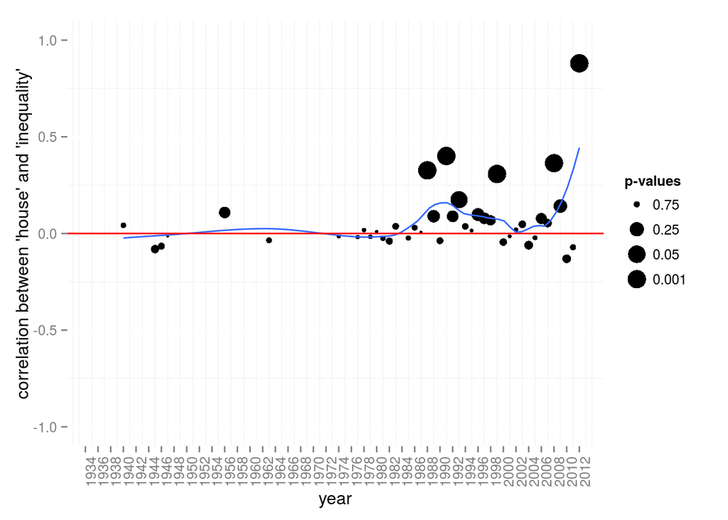

Figure 16: Correlation of inequality and house

#### Top words related to inequality over time

Top words in all documents containing “inequality” show that focuses change with time. Figure 17 shows that top words shift from population, organization, and mound to ritual, power and pottery. This indicates that archaeologists focus more on anthropological questions recently since 2006. Moreover, the term “river” and “coast” are also top words associated with inequality recently. These geographic features might indicate some conditions for social inequality. Based on the results, I further explore the correlation between “inequality” and “ritual” and “power” respectively. Figure 18 shows that there are several strong correlations between ritual and inequality at 1963, and moderate correlations at 1977, 1984, 2000 and 2011. On the other hand, Figure 19 shows strong correlations between inequality and power at 1979 and 1990, and several moderate correlations from 1978 to 2011. These patterns indicate that ritual and power are common topics that are associated with inequality. In addition, the discussion of power is later than the discussion of ritual.

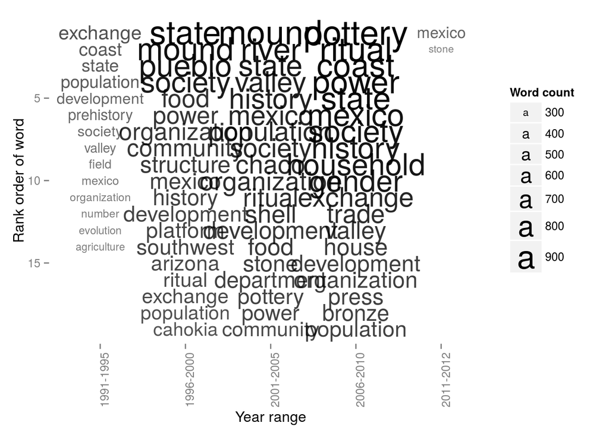

Figure17: The top words associated with inequality over time

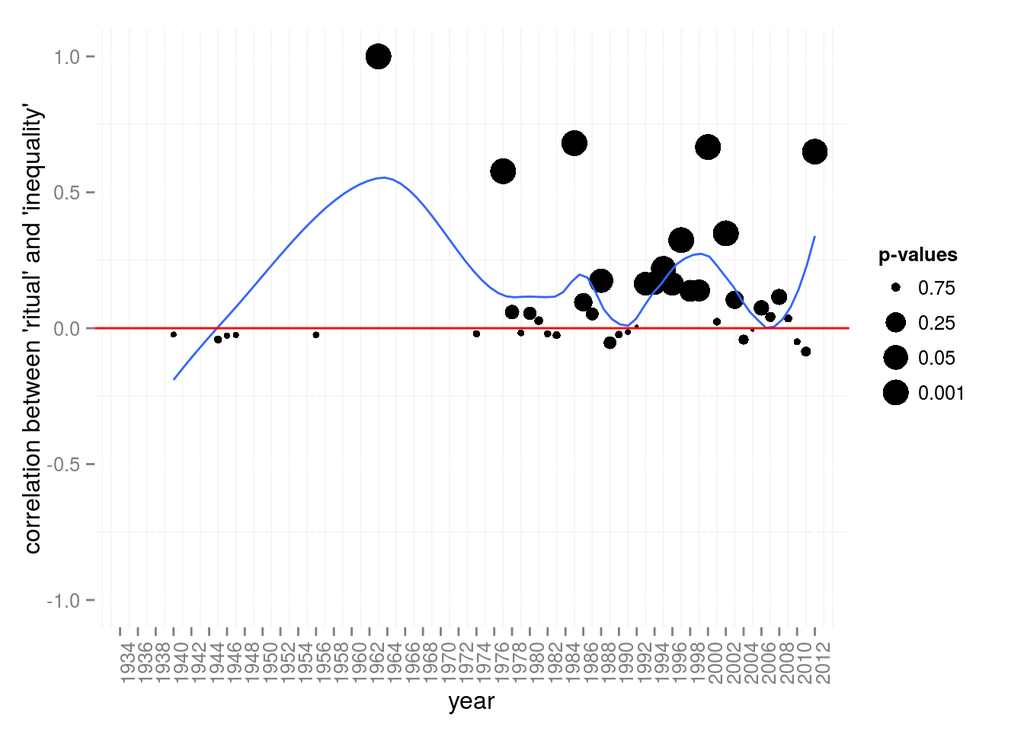

Figure18: Correlation of inequality and ritual

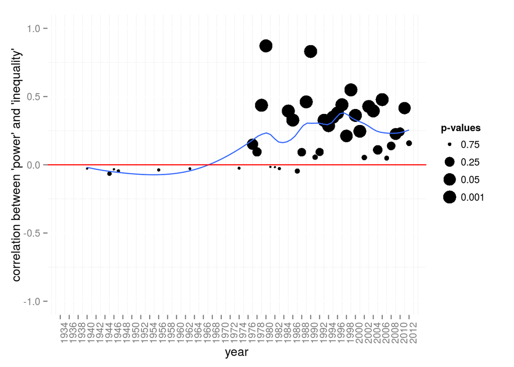

Figure19: Correlation of inequality and power

Reference

Ames, Kenneth. 2007. “The Archaeology of Rank.” In *Handbook of Archaeological Theories*, edited by R Alexander Bentley, Herbert D. G. Maschner, and Christopher Chippindale, 487–513. Altamira Press.

Arponen, VPJ, Johannes Müller, Robert Hofmann, Martin Furholt, Artur Ribeiro, Christian Horn, and Martin Hinz. 2015. “Using the Capability Approach to Conceptualise Inequality in Archaeology: The Case of the Late Neolithic Bosnian Site Okolište c. 5200–4600 Bce.” *Journal of Archaeological Method and Theory*, 1–20.

Bowles, Samuel, Eric Alden Smith, and Monique Borgerhoff Mulder. 2010. “The Emergence and Persistence of Inequality in Premodern Societies.” *Current Anthropology* 51 (1): 7–17.

Crumley, Carole L. 1995. “Heterarchy and the Analysis of Complex Societies.” *Archeological Papers of the American Anthropological Association* 6 (1): 1–5.

Fogelin, Lars. 2007. “Inference to the Best Explanation: A Common and Effective Form of Archaeological Reasoning.” *American Antiquity* Vol. 72 (No. 4): pp. 603–25.

Jones, A, and Benjamin Alberti. 2013. “Archaeology After Interpretation.” In *Archaeology After Interpretation: Returning Materials to Archaeological Theory*, edited by Joshua Pollard, A Jones, and Benjamin Alberti, 15–35. Left Coast Press.

Laguens, Andrés. 2014. “Social Space and the Archaeology of Inequality: Insights into Social Differences at Ambato Valley, Southern Andes, Argentina.” In *Against Typological Tyranny in Archaeology*, edited by Cristóbal Gnecco and Carl Langebaek, 75–98. Springer.

Price, T Douglas, and Gary M Feinman. 2010. “Social Inequality and the Evolution of Human Social Organization.” In *Pathways to Power: New Perspectives on the Emergence of Social Inequality*, edited by T Douglas Price and Gary M Feinman, 1–14. Springer Science & Business Media.

Shanks, Michael, and Ian Hodder. 2007. “Processual, Postprocessual and Interpretive Archaeologies.” In *Museums in the Material World*, edited by Simon Knell, 144–65. Routledge.